# 위암(Gastric) 임상 코호트 분석

**목표.** 진행 중인 위암(Gastric) 임상 코호트를 ClinicalTrials.gov 전량 수집 데이터로 분석하여, (1) 표준치료 **B(대조군/backbone)** 데이터 자산을 수요 폭 기준으로 우선순위화하고, (2) **코호트 유사도 2D 맵 + 군집화**로 제약사들이 집중하는 코호트 분포를 시각화한다. 빅파마 참여 임상을 강조 표시해 **먼저 접근할 코호트**를 선별한다.

핵심 통찰: `A + B vs B`(또는 `A vs B`) 구조에서 **B는 표준치료**이며, 스폰서들은 공통적으로 "B 치료에 따른 종양미세환경(TME) 변화·반응 바이오마커"를 원한다 → B의 실제 TME 데이터는 그 B를 쓰는 진행 중 임상이 많을수록 가치가 높다.

```
Gastric: industry-led trials 228 / 287 (academic/other excluded)
```

|  | nct_id | brief_title | phase | phase_simple | overall_status | enrollment | lead_sponsor | company | sponsor_scale | is_industry | ... | tme_relevant | is_combination | HER2 | CLDN18.2 | MSI-H/dMMR | PD-L1_CPS | EBV | first_line | later_line | biomarker_selected |
| --- | --- | --- | --- | --- | --- | --- | --- | --- | --- | --- | --- | --- | --- | --- | --- | --- | --- | --- | --- | --- | --- |
| 0 | NCT02584244 | Feasibility of the LUM Imaging System for Dete... | PHASE1;PHASE2 | Phase 2 | RECRUITING | 66 | Lumicell, Inc. | Lumicell | 9 | 1 | ... | 0 | 1 | 0 | 0 | 0 | 0 | 0 | 0 | 0 | 0 |
| 1 | NCT02734004 | A Phase I/II Study of MEDI4736 in Combination ... | PHASE1;PHASE2 | Phase 2 | ACTIVE_NOT_RECRUITING | 264 | AstraZeneca | AstraZeneca | 780 | 1 | ... | 0 | 1 | 1 | 0 | 0 | 1 | 0 | 0 | 1 | 1 |
| 2 | NCT03132922 | MAGE-A4ᶜ¹º³²T for Multi-Tumor | PHASE1 | Phase 1 | ACTIVE_NOT_RECRUITING | 71 | USWM CT, LLC | USWM CT | 8 | 1 | ... | 1 | 1 | 0 | 0 | 0 | 0 | 0 | 0 | 0 | 0 |

3 rows × 28 columns

## 1. EDA — 수집 데이터 분포 점검

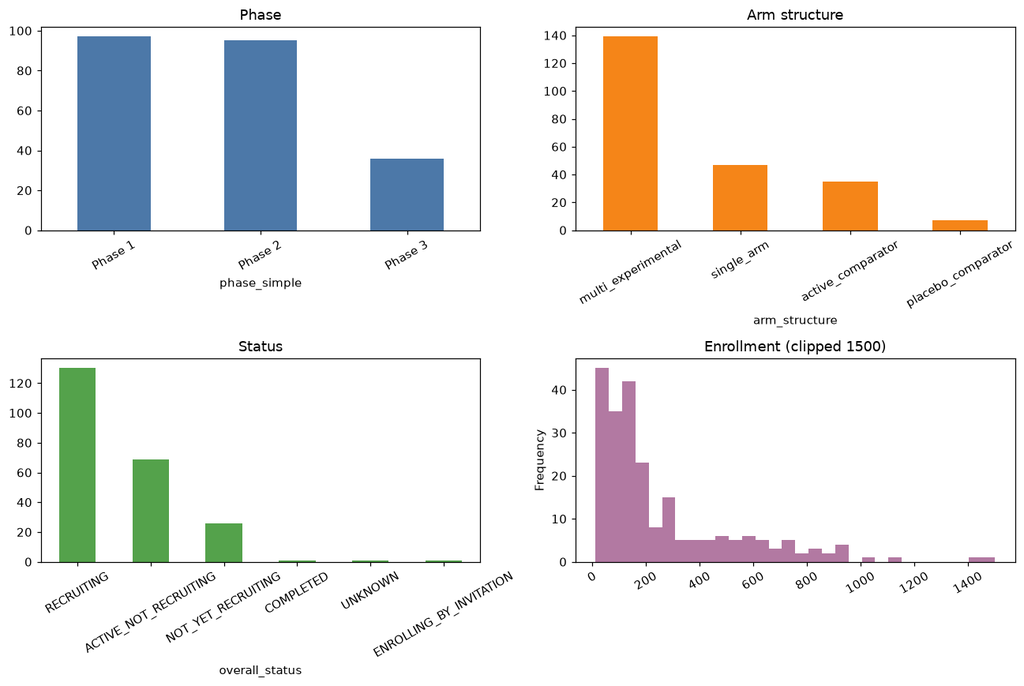

```
Industry-led: 228 | Big pharma involved: 66
TME-relevant modality: 145 | Biomarker-selected eligibility: 136
```

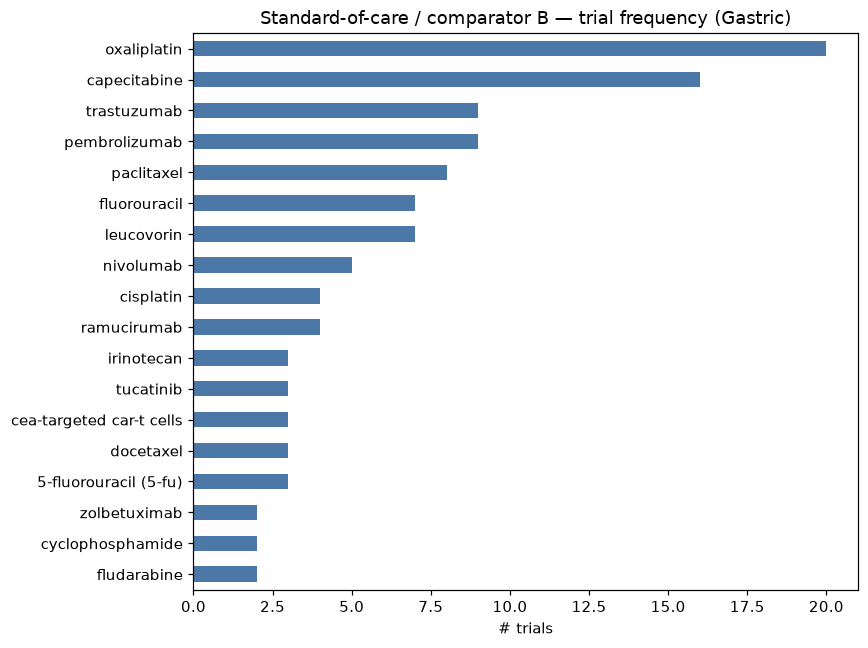

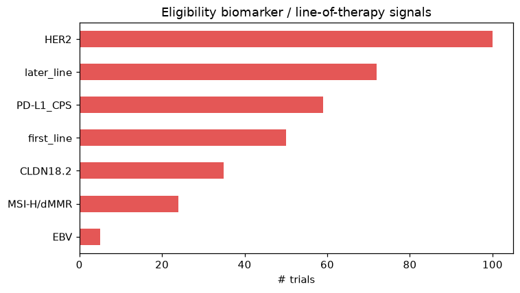

## 1-B. 표준치료(SoC) 대조군 코호트 분류 (정규화 보정 포함)

각 임상의 대조군/backbone을 스캔해 **확립된 표준치료(SoC)가 있는 코호트**와 아닌 것으로 나눈다. 레지멘 변형(`FLOT regimen`), 복합 표기(`trastuzumab + XELOX`), generic 표기(`standard of care`, `investigator's choice`)까지 substring으로 인식해 정규화 누락을 보정한다. 비-SoC는 ① 대조군 없음(단일군/비대조), ② novel 신약만, ③ 비약물(수술·기기·진단)으로 세분한다.

```
cohort_class
novel drug only (no SoC)        157
SoC-anchored                     64
non-drug (surgery/device/dx)      7

SoC-anchored: 64 / 228
```

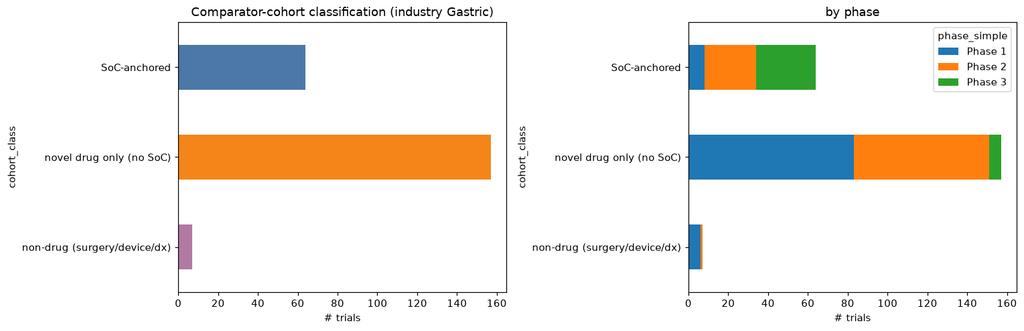

```
SoC-anchored 코호트의 치료 계열 분포:
soc_class
chemo                   24
IO;chemo                12
IO                       7
HER2                     6
anti_VEGF;chemo          5
HER2;chemo               3
HER2;IO;chemo            3
CLDN18.2                 1
SoC_generic;chemo        1
HER2;anti_VEGF;chemo     1
CLDN18.2;IO;chemo        1
```

## 2. Feature engineering — 표준치료 **성분(component)** 인코딩

**바이오마커·타겟·모달리티·arm 구조 등은 제외.** SoC-anchored 코호트만 남긴다. 군집화 feature는 표준치료를 **성분 약물 수준**으로 인코딩한다(FOLFOX→5FU+leucovorin+oxaliplatin). 이유: 레지멘을 원자 feature로 두면 "3개 중 2개만" 쓴 케이스나 유사 레지멘이 코사인 유사도 0으로 분리되지만, 성분으로 두면 **부분 겹침이 반영**돼 임상적으로 가까운 코호트가 가깝게 위치한다. 레지멘 라벨(`B_soc`)은 클러스터 해석·카드 표시용으로만 유지.

```
standard-of-care anchored cohorts: 64  (from 228 industry Gastric trials)
feature matrix (SoC components): (64, 22)
성분 feature: ['B=capecitabine', 'B=cisplatin', 'B=docetaxel', 'B=durvalumab', 'B=fluorouracil', 'B=gemcitabine', 'B=irinotecan', 'B=leucovorin', 'B=nivolumab', 'B=oxaliplatin', 'B=paclitaxel', 'B=pembrolizumab', 'B=ramucirumab', 'B=s-1', 'B=sintilimab', 'B=standard_of_care', 'B=tislelizumab', 'B=tras…
```

## 2-B. 레지멘 수준 데이터 (별도 표시)

군집은 성분 기반이지만, 사람이 읽기 좋은 **레지멘 관점**으로도 따로 집계한다: 각 코호트의 **화학요법 backbone**과 **추가 표적·면역 약물**(+anti-VEGF/+anti-EGFR/+IO/+HER2/+CLDN18.2)을 조합해 분포를 본다.

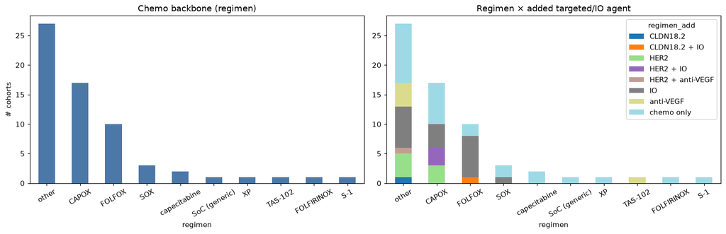

```
레지멘 × 추가약물 교차표:
regimen_add    CLDN18.2  CLDN18.2 + IO  HER2  HER2 + IO  HER2 + anti-VEGF  IO  anti-VEGF  chemo only
regimen
CAPOX                 0              0     3          3                 0   4          0           7
FOLFIRINOX            0              0     0          0                 0   0          0           1
FOLFOX                0              1     0          0                 0   7          0           2
S-1                   0              0     0          0                 0   0          0           1
SOX                   0              0     0          0                 0   1          0           2
SoC (generic)         0              0     0          0                 0   0          0           1
TAS-102               0              0     0          0                 0   0          1           0
XP                    0              0     0          0                 0   0          0           1
capecitabine          0              0     0          0                 0   0          0           2
other                 1              0     4          0                 1   7          4          10
```

## 3. 차원축소 & 군집화 — 치료구성 cosine 공간에서 KMeans (silhouette로 k 선택)

```
k=4  silhouette=0.247  sizes=[np.int64(22), np.int64(15), np.int64(14), np.int64(13)]
k=5  silhouette=0.283  sizes=[np.int64(22), np.int64(14), np.int64(13), np.int64(9), np.int64(6)]
k=6  silhouette=0.293  sizes=[np.int64(15), np.int64(14), np.int64(13), np.int64(10), np.int64(6), np.int64(6)]
k=7  silhouette=0.293  sizes=[np.int64(19), np.int64(13), np.int64(11), np.int64(9), np.int64(4), np.int64(4), np.int64(4)]
k=8  silhouette=0.299  sizes=[np.int64(18), np.int64(13), np.int64(9), np.int64(8), np.int64(6), np.int64(4), np.int64(4), np.int64(2)]
chosen k = 8
```

## 4. 클러스터 프로파일링 — 아키타입 명명

|  | cluster | n | top_B | top_target | top_modality | phase_mix | bigpharma | biomarker_sel% |
| --- | --- | --- | --- | --- | --- | --- | --- | --- |
| 0 | 0 | 9 | irinotecan, paclitaxel, docetaxel | CLDN18.2, HER2, PD-1 | ADC, Monoclonal Antibody, Small Molecule | Phase 3:7, Phase 2:2 | 2 | 89 |
| 1 | 1 | 18 | CAPOX, capecitabine, SOX | PD-1, HER2, CLDN18.2 | Monoclonal Antibody, ADC, Small Molecule | Phase 3:10, Phase 2:7, Phase 1:1 | 1 | 78 |
| 2 | 2 | 6 | trastuzumab, tucatinib, trastuzumab deruxtecan | HER2, VEGF/VEGFR | Small Molecule, Monoclonal Antibody, ADC | Phase 2:3, Phase 1:2, Phase 3:1 | 4 | 100 |
| 3 | 3 | 2 | nivolumab | PD-1 | Monoclonal Antibody, Bispecific Antibody | Phase 2:1, Phase 3:1 | 1 | 50 |
| 4 | 4 | 13 | FOLFOX, pembrolizumab, capecitabine | PD-1, CLDN18.2, FGFR2 | Monoclonal Antibody, Small Molecule, Vaccine | Phase 3:6, Phase 2:5, Phase 1:2 | 6 | 92 |
| 5 | 5 | 8 | paclitaxel, ramucirumab, zolbetuximab | VEGF/VEGFR, CLDN18.2, 5T4 | Monoclonal Antibody, ADC | Phase 2:4, Phase 1:2, Phase 3:2 | 5 | 88 |
| 6 | 6 | 4 | pembrolizumab, nivolumab | MAGE-A4, IL-2, PD-1 | Cell Therapy, Small Molecule, Monoclonal Antibody | Phase 2:3, Phase 1:1 | 3 | 50 |
| 7 | 7 | 4 | CAPOX, FP, trastuzumab | HER2, PD-L1 | Monoclonal Antibody, Bispecific Antibody, ADC | Phase 3:3, Phase 2:1 | 2 | 100 |

## 5. 코호트 유사도 2D 맵 — 클러스터 · Phase · 빅파마 강조

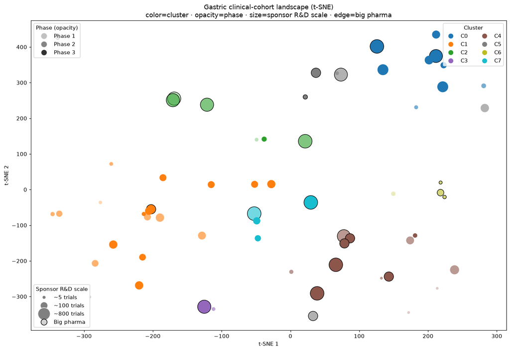

## 5-B. 클러스터별 대표 빅파마 코호트

각 클러스터의 중심(군집 특성공간)에서 **가장 가까운 빅파마 코호트**를 대표로 뽑아 코호트 정의를 정리한다. 대표 제약사·대조군 치료(B)·바이오마커와, 그 클러스터에 함께 속한 다른 제약사들을 표로.

```
saved outputs/cluster_representatives_gastric.csv
```

|  | cluster | n | 대표 제약사 | 대조군 치료 B | 바이오마커 | phase | 대표 NCT | 다른 제약사 |
| --- | --- | --- | --- | --- | --- | --- | --- | --- |
| 0 | 0 | 9 | Merck Sharp & Dohme LLC | docetaxel;irinotecan;paclitaxel | HER2 | Phase 3 | NCT06356311 | Jiangsu HengRui Medicine Co., Ltd., CARsgen Therapeutics... |
| 1 | 1 | 18 | Astellas Pharma Global Development, Inc. | CAPOX | HER2, CLDN18.2 | Phase 3 | NCT03653507 | Suzhou Suncadia Biopharmaceuticals Co., Ltd., Ono Pharma... |
| 2 | 2 | 6 | Seagen, a wholly owned subsidiary of Pfizer | trastuzumab;tucatinib | HER2, PD-L1_CPS | Phase 2 | NCT04430738 | Pfizer, AstraZeneca, Enliven Therapeutics, SUNHO（China）B... |
| 3 | 3 | 2 | Pfizer | nivolumab | PD-L1_CPS | Phase 3 | NCT07392892 | Teclison Ltd. |
| 4 | 4 | 13 | Astellas Pharma Global Development, Inc. | FOLFOX | HER2, CLDN18.2 | Phase 3 | NCT03504397 | BioEclipse Therapeutics, Bold Therapeutics, Inc., Taiho ... |
| 5 | 5 | 8 | Daiichi Sankyo | paclitaxel;ramucirumab | HER2 | Phase 3 | NCT04704934 | Astellas Pharma Global Development, Inc., NeoTX Therapeu... |
| 6 | 6 | 4 | Medicenna Therapeutics, Inc. | pembrolizumab | - | Phase 2 | NCT05086692 | USWM CT, LLC, Qurient Co., Ltd., Servier Bio-Innovation LLC |
| 7 | 7 | 4 | AstraZeneca | CAPOX;FP;trastuzumab | HER2 | Phase 2 | NCT04379596 | Jazz Pharmaceuticals, Shanghai JMT-Bio Inc. |

## 5-C. 인터랙티브 코호트 대시보드 (HTML)

`outputs/cohort_map_<slug>.html` — 좌: 코호트 맵, 우: ① 클러스터별 정보, ② **R&D 규모순 제약사 드롭다운** → 선택 시 맵에서 위치 하이라이트 + 그 제약사 임상의 ClinicalTrials.gov 링크·상세 카드. 맵의 점 클릭·hover(제약사·레지멘·Phase·status)도 지원.

```
saved /Users/minsung.choi/clinical_data_finder/outputs/cohort_map_gastric.html
```

## 6. 가치 랭킹 — 표준치료 B 데이터 자산 (수요 폭 중심)

각 B에 대해: **demand_breadth**(그 B를 쓰는 진행 중 트라이얼 수, 주축) + 스폰서 다양성 + 빅파마 수 + phase 가중 + 등록 규모 + TME 관련성 + 바이오마커 개방성.

|  | B (standard therapy) | demand_breadth | sponsors | bigpharma | phase_weight | n_phase3 | enroll_sum | tme_rel% | biomarker% | value_score |
| --- | --- | --- | --- | --- | --- | --- | --- | --- | --- | --- |
| 0 | CAPOX | 17 | 13 | 4 | 43.4 | 12 | 8276 | 94 | 88 | 0.940198 |
| 1 | paclitaxel | 13 | 11 | 5 | 32.0 | 8 | 4385 | 100 | 100 | 0.771618 |
| 2 | pembrolizumab | 12 | 11 | 7 | 27.0 | 6 | 4451 | 83 | 83 | 0.744107 |
| 3 | FOLFOX | 11 | 9 | 6 | 26.0 | 6 | 5918 | 82 | 100 | 0.678327 |
| 4 | trastuzumab | 11 | 8 | 5 | 26.8 | 7 | 4661 | 91 | 100 | 0.650649 |
| 5 | capecitabine | 9 | 7 | 4 | 20.0 | 4 | 4573 | 89 | 89 | 0.531963 |
| 6 | irinotecan | 8 | 7 | 2 | 21.2 | 6 | 2919 | 88 | 88 | 0.463133 |
| 7 | nivolumab | 7 | 7 | 2 | 14.8 | 3 | 4450 | 100 | 71 | 0.418098 |
| 8 | ramucirumab | 6 | 6 | 4 | 15.2 | 4 | 1927 | 100 | 100 | 0.409174 |
| 9 | docetaxel | 6 | 6 | 2 | 18.0 | 6 | 2758 | 83 | 100 | 0.381236 |
| 10 | FP | 4 | 3 | 2 | 10.6 | 3 | 2702 | 100 | 100 | 0.264909 |
| 11 | zolbetuximab | 2 | 2 | 2 | 4.6 | 1 | 2273 | 100 | 100 | 0.169298 |
| 12 | tislelizumab | 3 | 3 | 0 | 6.2 | 1 | 708 | 100 | 100 | 0.164477 |
| 13 | SOX | 3 | 2 | 0 | 7.6 | 2 | 1612 | 100 | 33 | 0.138892 |
| 14 | tucatinib | 3 | 2 | 3 | 4.2 | 0 | 119 | 0 | 100 | 0.116527 |

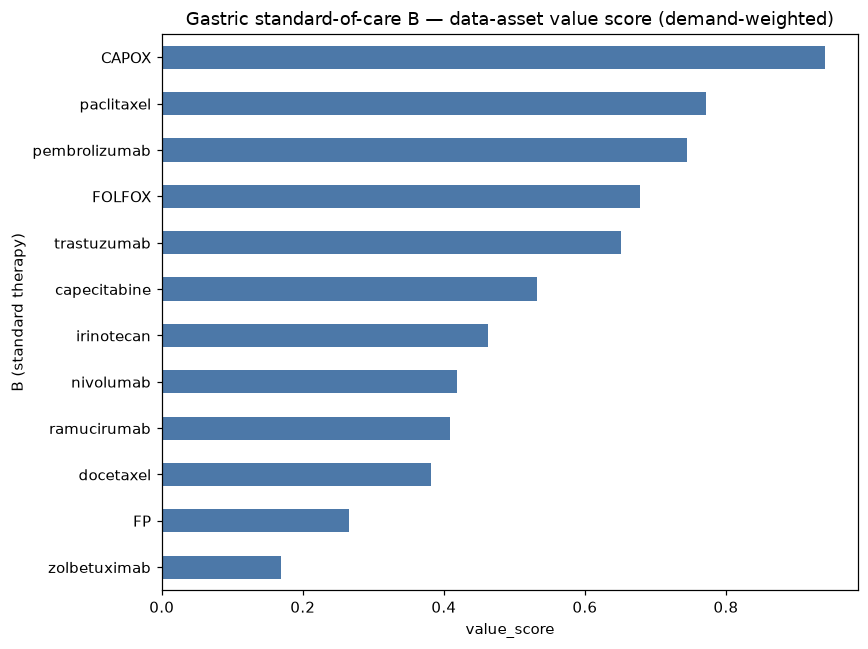

## 7. 먼저 접근할 코호트 — 빅파마 참여 + Phase 3 우선

|  | nct_id | phase_simple | lead_sponsor | B_soc | targets | enrollment | arm_structure | biomarker_selected |
| --- | --- | --- | --- | --- | --- | --- | --- | --- |
| 55 | NCT07431281 | Phase 3 | AstraZeneca | FOLFOX;capecitabine;nivolumab;zolbetuximab | PD-1 | 2130 | active_comparator | 1 |
| 43 | NCT06764875 | Phase 3 | AstraZeneca | CAPOX;FP;pembrolizumab;trastuzumab | HER2 | 840 | active_comparator | 1 |
| 54 | NCT07392892 | Phase 3 | Pfizer | nivolumab | PD-1 | 840 | active_comparator | 1 |
| 50 | NCT07221149 | Phase 3 | Bristol-Myers Squibb | CAPOX;FOLFOX | PD-1 | 690 | multi_experimental | 1 |
| 36 | NCT06346392 | Phase 3 | AstraZeneca | docetaxel;irinotecan;paclitaxel;ramucirumab;trifluridine... | CLDN18.2 | 594 | active_comparator | 1 |
| 61 | NCT07673887 | Phase 3 | Astellas Pharma Global Development, Inc. | FOLFOX;capecitabine;pembrolizumab | CLDN18.2 | 570 | placebo_comparator | 1 |
| 1 | NCT03504397 | Phase 3 | Astellas Pharma Global Development, Inc. | FOLFOX | CLDN18.2 | 565 | placebo_comparator | 1 |
| 3 | NCT03653507 | Phase 3 | Astellas Pharma Global Development, Inc. | CAPOX | CLDN18.2 | 507 | placebo_comparator | 1 |
| 45 | NCT06901531 | Phase 3 | Astellas Pharma Global Development, Inc. | FOLFOX;capecitabine;pembrolizumab | CLDN18.2 | 500 | active_comparator | 1 |
| 12 | NCT04704934 | Phase 3 | Daiichi Sankyo | paclitaxel;ramucirumab | VEGF/VEGFR | 490 | active_comparator | 1 |
| 37 | NCT06356311 | Phase 3 | Merck Sharp & Dohme LLC | docetaxel;irinotecan;paclitaxel | TROP-1 | 450 | active_comparator | 1 |
| 14 | NCT05002127 | Phase 3 | ALX Oncology Inc. | paclitaxel;ramucirumab;trastuzumab | CD47 | 127 | active_comparator | 1 |
| 8 | NCT04379596 | Phase 2 | AstraZeneca | CAPOX;FP;trastuzumab | PD-L1 | 452 | active_comparator | 1 |
| 39 | NCT06445972 | Phase 2 | Merck Sharp & Dohme LLC | paclitaxel;ramucirumab | VEGF/VEGFR | 210 | active_comparator | 1 |
| 40 | NCT06469944 | Phase 2 | Merck Sharp & Dohme LLC | FOLFOX;capecitabine;pembrolizumab | PD-1 | 160 | active_comparator | 1 |
| 2 | NCT03505320 | Phase 2 | Astellas Pharma Global Development, Inc. | zolbetuximab | CLDN18.2 | 143 | multi_experimental | 1 |
| 33 | NCT06271837 | Phase 2 | AstraZeneca | trastuzumab;trastuzumab deruxtecan | VEGF/VEGFR | 127 | multi_experimental | 1 |
| 20 | NCT05438420 | Phase 2 | Qurient Co., Ltd. | pembrolizumab | PD-1 | 120 | multi_experimental | 1 |
| 15 | NCT05086692 | Phase 2 | Medicenna Therapeutics, Inc. | pembrolizumab | IL-2 | 115 | single_arm | 0 |
| 29 | NCT06157892 | Phase 2 | Seagen, a wholly owned subsidiary of Pfizer | tucatinib | HER2 | 54 | multi_experimental | 1 |

## 8. 요약

- **가치 랭킹(`outputs/value_ranking_gastric.csv`)**: 위암(Gastric)에서 TME 데이터를 만들면 가장 많은 스폰서가 원할 표준치료 B 순위.
- **코호트 맵/대시보드(`outputs/cohort_map_gastric.png` / `.html`)**: 제약사들이 집중하는 코호트 아키타입 분포, Phase·빅파마 강조.
- **먼저 접근할 코호트**: 빅파마 참여 + Phase 3 pivotal 우선.